# Analysis of Red Wine Quality by Yasaman Jalili

# Plots and Analysis

First, I look at the summary of all the variables and their histograms to get a better sense of the dataset:

```
##        X          fixed.acidity   volatile.acidity  citric.acid
##  Min.   :   1.0   Min.   : 4.60   Min.   :0.1200   Min.   :0.000
##  1st Qu.: 400.5   1st Qu.: 7.10   1st Qu.:0.3900   1st Qu.:0.090
##  Median : 800.0   Median : 7.90   Median :0.5200   Median :0.260
##  Mean   : 800.0   Mean   : 8.32   Mean   :0.5278   Mean   :0.271
##  3rd Qu.:1199.5   3rd Qu.: 9.20   3rd Qu.:0.6400   3rd Qu.:0.420
##  Max.   :1599.0   Max.   :15.90   Max.   :1.5800   Max.   :1.000
##  residual.sugar     chlorides       free.sulfur.dioxide
##  Min.   : 0.900   Min.   :0.01200   Min.   : 1.00
##  1st Qu.: 1.900   1st Qu.:0.07000   1st Qu.: 7.00
##  Median : 2.200   Median :0.07900   Median :14.00
##  Mean   : 2.539   Mean   :0.08747   Mean   :15.87
##  3rd Qu.: 2.600   3rd Qu.:0.09000   3rd Qu.:21.00
##  Max.   :15.500   Max.   :0.61100   Max.   :72.00
##  total.sulfur.dioxide    density             pH          sulphates
##  Min.   :  6.00       Min.   :0.9901   Min.   :2.740   Min.   :0.3300
##  1st Qu.: 22.00       1st Qu.:0.9956   1st Qu.:3.210   1st Qu.:0.5500
##  Median : 38.00       Median :0.9968   Median :3.310   Median :0.6200
##  Mean   : 46.47       Mean   :0.9967   Mean   :3.311   Mean   :0.6581
##  3rd Qu.: 62.00       3rd Qu.:0.9978   3rd Qu.:3.400   3rd Qu.:0.7300
##  Max.   :289.00       Max.   :1.0037   Max.   :4.010   Max.   :2.0000
##     alcohol      quality     rating
##  Min.   : 8.40   3: 10   poor   :  10
##  1st Qu.: 9.50   4: 53   average:1372
##  Median :10.20   5:681   good   : 217
##  Mean   :10.42   6:638
##  3rd Qu.:11.10   7:199
##  Max.   :14.90   8: 18
```

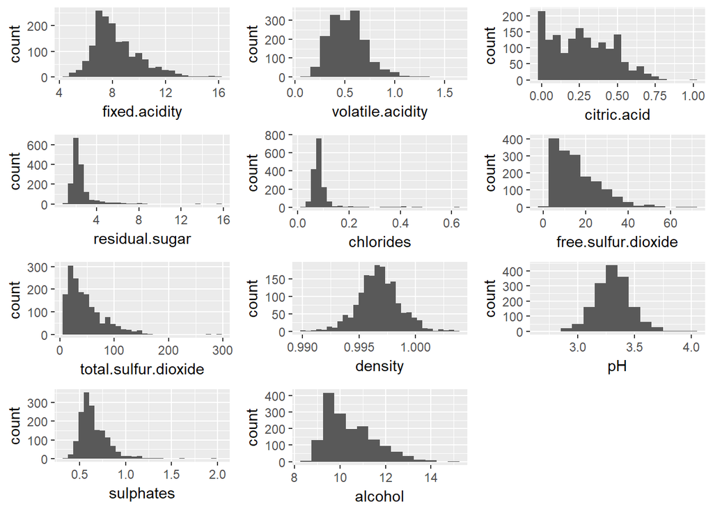

The variables “fixed acidity”, “volatile acidity”, “pH”, and “density” are normally distributed. Most of the “pH” is between 3.2 and 3.4 and the mean ‘density’ of the wine is 0.996 g/cm<sup>3</sup> which is close to the density of water (1 g/cm<sup>3</sup>).

“Residual sugar”, “chlorides”, and “sulphates” are also normally distributed but have some outliers that makes the the right tail longer. The majority of “residual sugar”, “chlorides”, and “sulphates” is less than 4, 0.4, and 1 g/dm<sup>3</sup> respectively.

“Citric acid”, “total sulfure dioxide”, and “free sulfure dioxide” are skewed to the right with “Citric acid” having 132 observations with the value 0 (8.25% of total observations).

```
## [1] "citric acid"
```

```
## [1] "count of 0 values: 132"
```

```
## [1] "percent of 0 values: 8.26"
```

Both the mean and median of the “alcohol” are 10% with the distirubtion having a slightly heavy right tail.

To see the distributaion of “residual sugar”, “chlorides”, and “sulfates” better, I redraw the plots, using a log tranform for the x-axis:

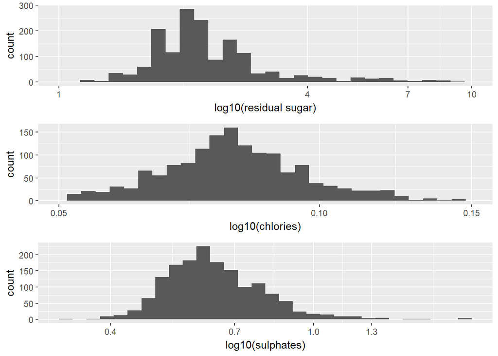

These new plots handle the outliers better and show the distributions more clearly.

Next, I investigate what is the median of each input varaible for various quality scores.

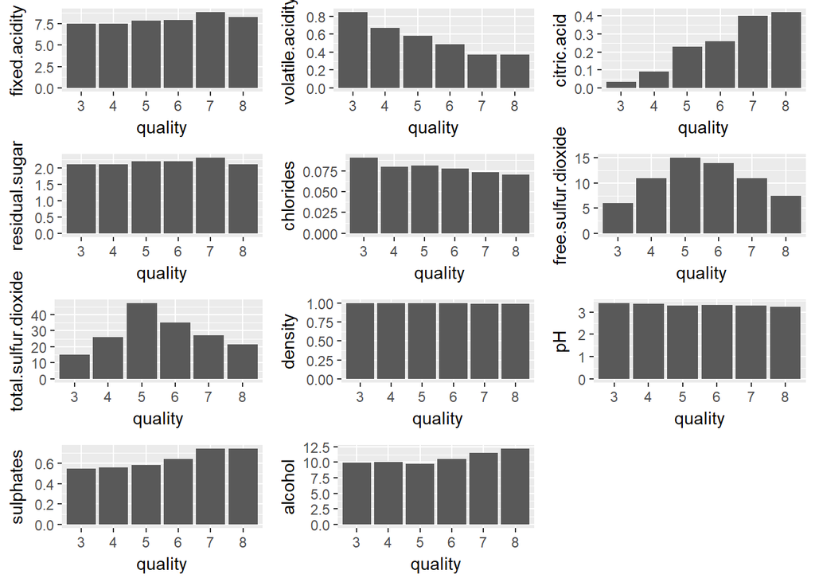

The bar charts show that higher values of “volatile acidity” are associated with lower quality wine and higher amounts of “citric acid” are an attribute of higher quality wines. These results intuitively make sense because higher amounts of volatile acidity will create vinegar tasting wine and hence the lower quality score, while “citric acid” adds freshness to the wine and increases the quality. These two variables seem promising in developing a model to predict the quality score of a wine. The quality score of wine shows a slight increasing trend as the amount of alcohol and sulphates increases. Hence, it is useful to investigate these two variables further in the following sections.

Higher quantities of “free sulfur dioxide” and “total sulfur dioxide” are associated with average ratings of wine (scores of 4, 5 and 6), while both poor and good quality wine have lower quantities of these two variables.

The barcharts do not show any relationship between the remaining variables and the quality of wine.

Next, I will look at the box plots of the input variables for each quality score.

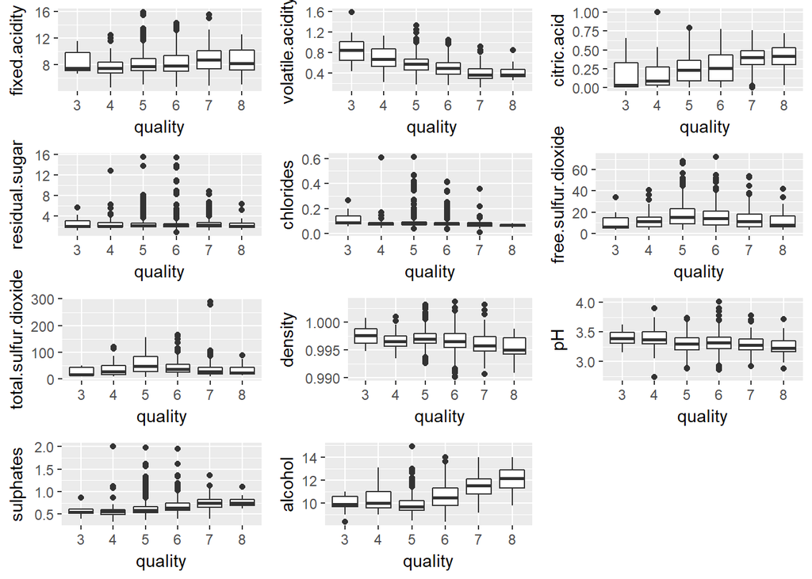

The boxplots highlight large number of outliers for “residual sugar”, “chlorides”, and “sulphates” as previously obsereved in the histograms. They also confirm the relationship between the quality of the wine and low amounts of “volatile acidity” and high amounts of “citric acid”. The relationships between the quality and “sulphates” and percentage of “alcohol” is more pronounced in the boxplots, making these two variables good candidates for a prediction model.

Next, I will look at the correlation among different input variables.

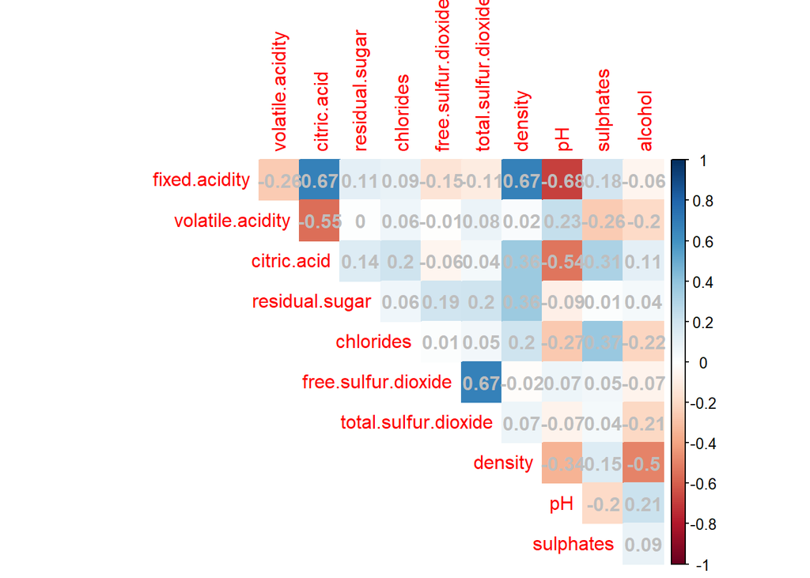

The plot shows that “fixed acidity” is positively correlated with “citric acid” and “density”, while it is negatively correlated with “pH”. The other correlation worth noting is the positive correlation between the “free sulfur dioxide” and “total sulfure dioxide”. Let’s take a closer look at the relationships between “fixed acidity” and “density”

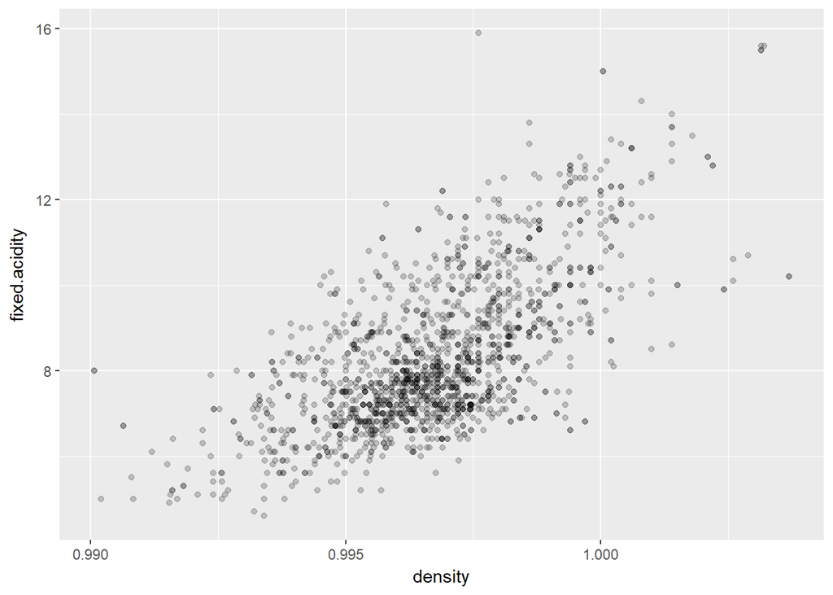

It looks that the variance increases as the “density” and “fixed acidity” increase. I am going to include only those observations with “density” lower than 1 (density of water) and add a new layer to depict the linear relationship between these two variables.

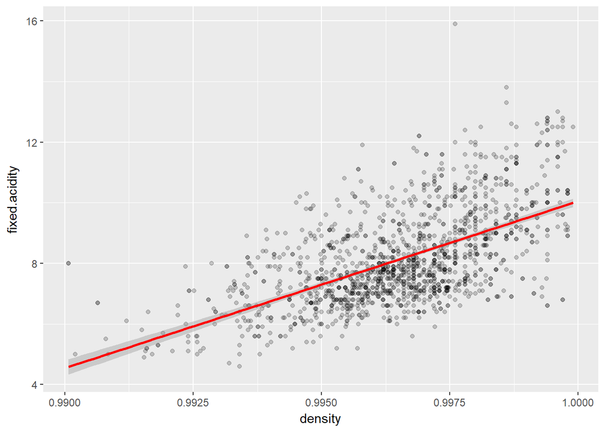

Then, I look at the relationship between “fixed acidity” and “density” for various quality scores:

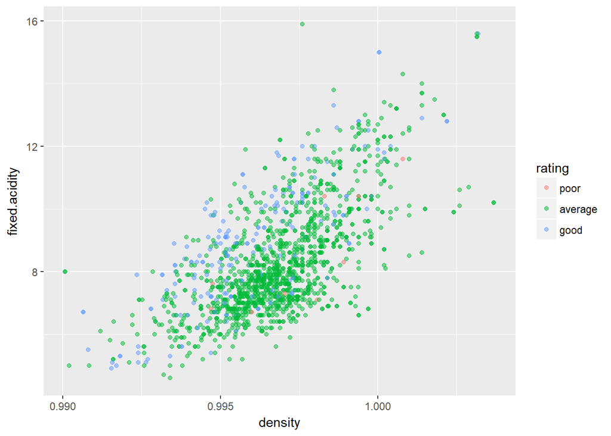

In all three cases, higher amounts of fixed acidity result in higher density in the red wine. The graph also shows that good quality red wines (color blue) tend to have higher amounts of fixed acidity. However, for poor quality data no particular trend can be easily observed.

Next, I want to look at the correlation between quality and input variables. For the rest of the study, I will use quality as an integer variable.

```
##                       [,1]
## fixed.acidity         0.12
## volatile.acidity     -0.39
## citric.acid           0.23
## residual.sugar        0.01
## chlorides            -0.13
## free.sulfur.dioxide  -0.05
## total.sulfur.dioxide -0.19
## density              -0.17
## pH                   -0.06
## sulphates             0.25
## alcohol               0.48
```

As suspected before, quality is moderately correlated with “alcohol” (correlation coefficient=0.48) and “volatile acidity” (correlation coefficient=-0.39). The other relationships worth considering in the model are “citric acid” and “sulfates”.

Since “volatile acidity” and “alcohol” have the highest correlation with the quality score of the wine, let’s take a closer look at these two variables. Next plot shows the relationshp between these two variables for different qualities of wine:

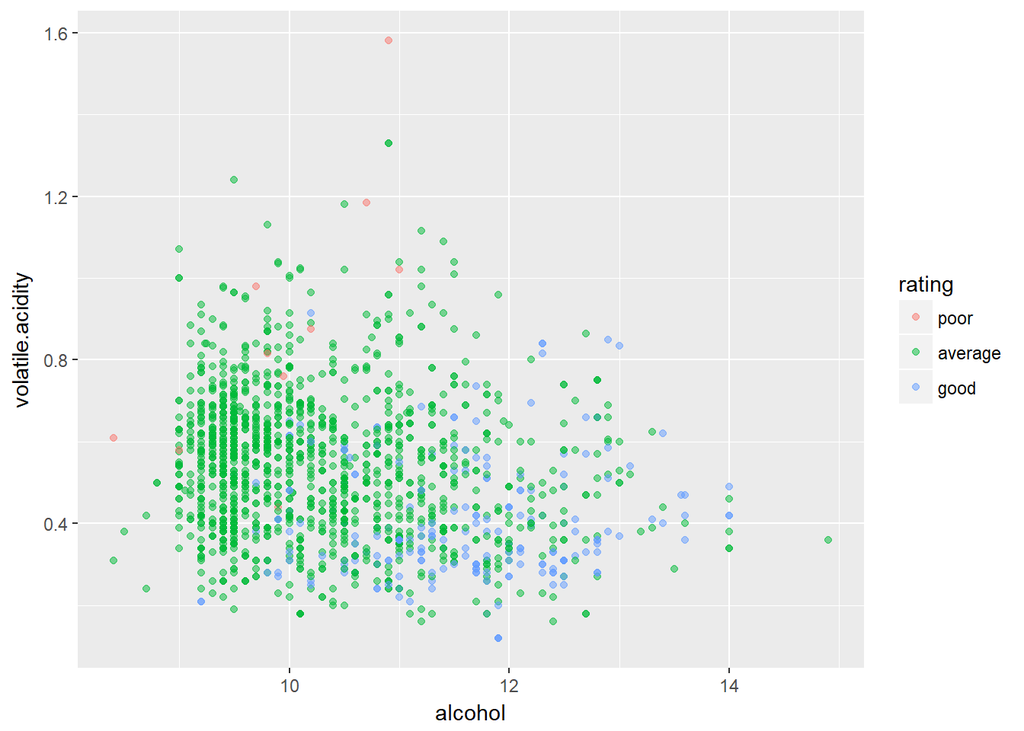

No apparent relationshp can be seen between “volatile acidity” and “alcohol”, however, higher quality red wines (color blue) tend to have higher percentage of alcohol and lower volatile acidity which is in accordance with the correlations found earliers in the correlation matrix.

For the final graph, I will create a matrix of plots for the promising input variables (“alcohol”, “volatile acidity”, “citric acid”, and “sulphates”).

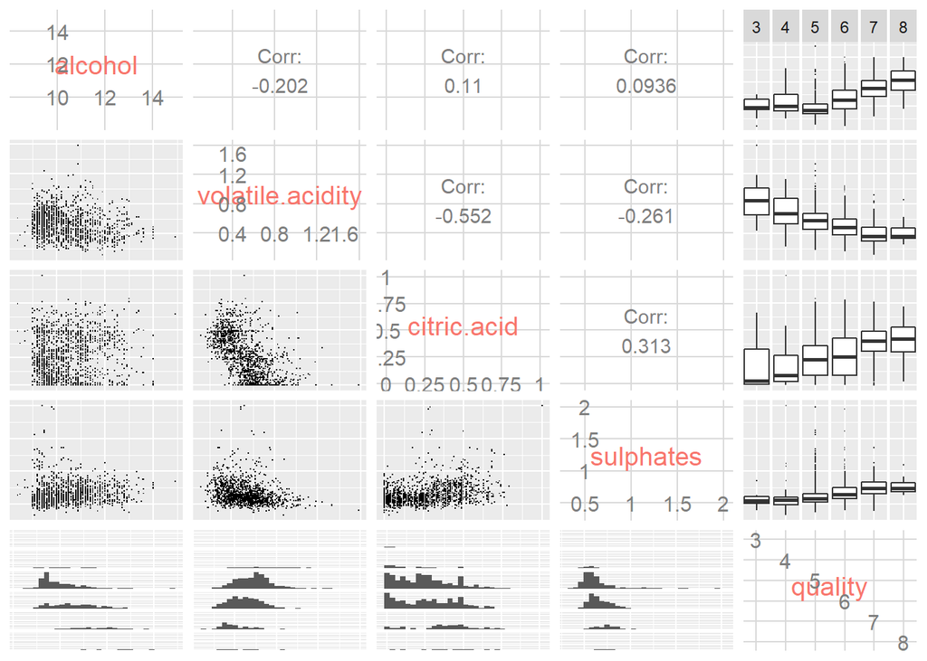

# Predictive Model

Here, I develop predictive model for wine quality. Since the output variable (‘quality’) is ordinal, I decided to develop an ordinal logistic regression. There are some assumptions using this type of model:

- dependent variable is ordinal
- independent observations
- independent variables are not correlated
- Proportional Odds

First, I divide my data into training and test sets.

Next, I will use the polr function from the MASS package to develop my model:

```
## Call:
## polr(formula = rating ~ alcohol + volatile.acidity + citric.acid +
##     sulphates, data = train, Hess = TRUE)
##
## Coefficients:
##                    Value Std. Error t value
## alcohol           0.9519    0.09264  10.276
## volatile.acidity -4.5601    0.72832  -6.261
## citric.acid       0.6014    0.58535   1.027
## sulphates         2.3471    0.51607   4.548
##
## Intercepts:
##              Value   Std. Error t value
## poor|average  3.2974  1.2030     2.7409
## average|good 11.9547  1.2350     9.6796
##
## Residual Deviance: 757.5729
## AIC: 769.5729
```

To get a better understanding of the significance of coefficients and intercepts, I used the t statistics to find the p-values and compared it to my confidence level (alpha=0.05).

```
##                       Value Std. Error   t value      p value
## alcohol           0.9519155 0.09263665 10.275798 9.059145e-25
## volatile.acidity -4.5601330 0.72832333 -6.261138 3.821776e-10
## citric.acid       0.6014156 0.58535114  1.027444 3.042113e-01
## sulphates         2.3471336 0.51607424  4.548054 5.414419e-06
## poor|average      3.2973837 1.20300825  2.740949 6.126210e-03
## average|good     11.9547213 1.23504333  9.679597 3.681653e-22
```

Looking at the results, all coefficients are statistically significant except for “citric acid”. Also, going back to the correlation matirx, you can see that there is a moderate correlation between “citric acid” and “volatile acidity”. So, I decided to remove this variable from the model and compare the two models using an ANOVA test.

```
## Likelihood ratio tests of ordinal regression models
##
## Response: rating
##                                                  Model Resid. df
## 1               alcohol + volatile.acidity + sulphates      1194
## 2 alcohol + volatile.acidity + citric.acid + sulphates      1193
##   Resid. Dev   Test    Df LR stat.   Pr(Chi)
## 1   758.6263
## 2   757.5729 1 vs 2     1 1.053374 0.3047313
```

Anova performs a chi-square test to compare the two models, since the value (0.3) is greater than the confidence level (0.05), these two models are not stistically significant. Hence, I will use the simpler model with only 3 variables as my predictive model. Here is the final model:

```
## Call:
## polr(formula = rating ~ alcohol + volatile.acidity + sulphates,
##     data = train, Hess = TRUE)
##
## Coefficients:
##                    Value Std. Error t value
## alcohol           0.9512    0.09262  10.270
## volatile.acidity -4.9074    0.64423  -7.618
## sulphates         2.4553    0.50601   4.852
##
## Intercepts:
##              Value   Std. Error t value
## poor|average  2.9927  1.1649     2.5691
## average|good 11.6630  1.1968     9.7455
##
## Residual Deviance: 758.6263
## AIC: 768.6263
```

```
##                       Value Std. Error   t value      p value
## alcohol           0.9511661 0.09261766 10.269813 9.639145e-25
## volatile.acidity -4.9074308 0.64422787 -7.617539 2.585582e-14
## sulphates         2.4553249 0.50601311  4.852295 1.220409e-06
## poor|average      2.9926538 1.16487043  2.569087 1.019668e-02
## average|good     11.6629530 1.19675062  9.745517 1.927959e-22
```

Next, I will use the model to predict the quality of wine in my test dataset.

Comparing the results of the predictive model with the actual quality score shows that the model is 87% accurate in predicting the wine quality.

```
## [1] "ordinal logistic regression model accuracy: 87%"
```

# Summary

Plot 1 shows the distribution of wine quality score.

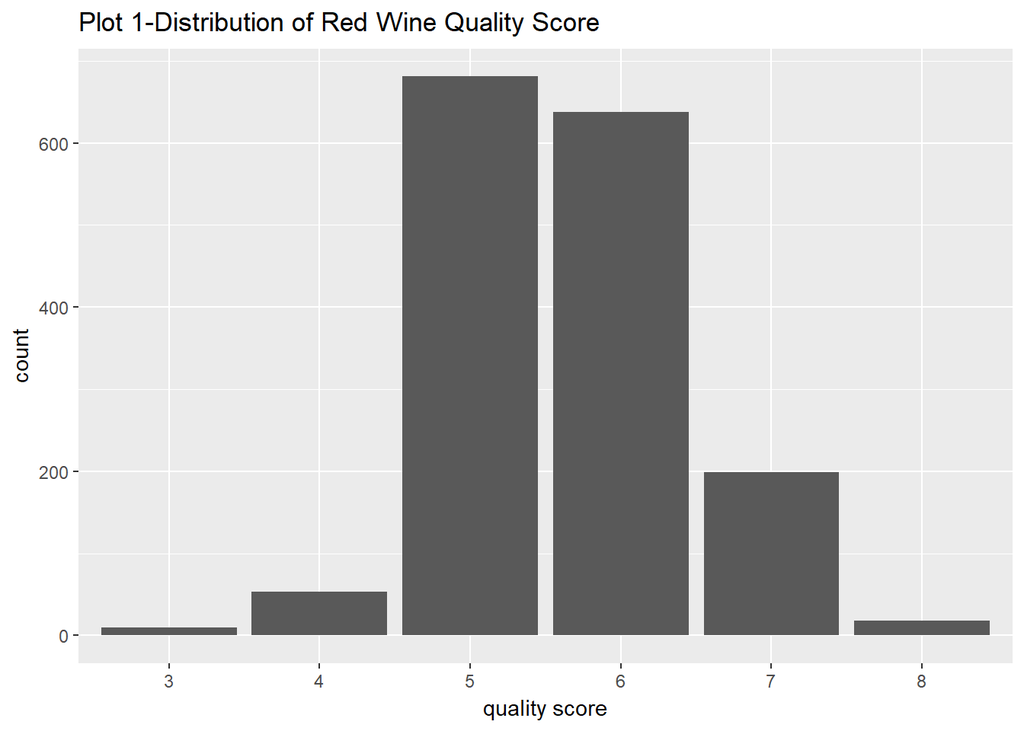

The plot shows that the majority of wine in the dataset was scored 5 or 6 and there is no sample that has been scored very poor (1 or 2) or very good (9 or 10). This might be because the wine tested was from a specific region that mostly provides average wine quality. This plot shows the biggest limitation of the dataset. Since the distribution is missing some of the extreme values, any predictive model based on this distribution will be limited.

The second plot shows the relationship between “volatile acidity” and “alcohol” for different qualities of wine:

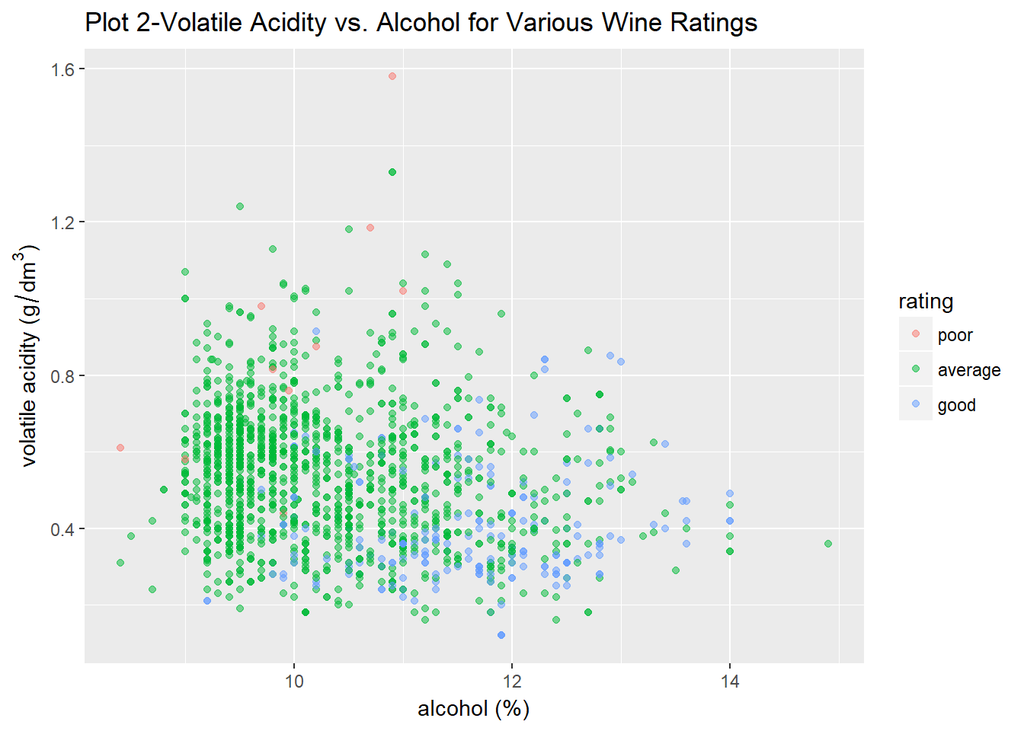

Plot 2 shows that higher quality red wines (color blue) tend to have higher percentage of alcohol and lower volatile acidity which is in accordance with the correlations found earliers in the correlation matrix.

Plot 3 shows the relationships between the output variable “qaulity” and four of the input variables: “volatile acidity”, “citric acid”, “sulphates”, “alcohol”

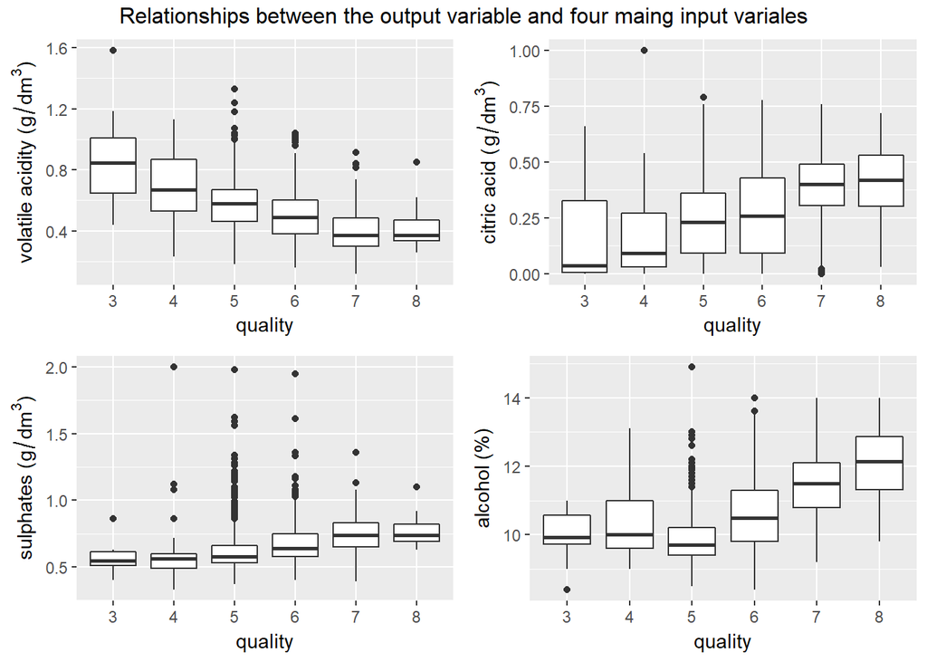

As the amount of “volatile acidity” decreases the quality score increases. Since higher amounts of “volatile acidity” contribute to having a vinegar like taste in the wine, the relationship revealed in the plot conforms with the intuition. “Citric acid” adds freshness to the wine and as we can see in the box plots, as the amount of “citric acid” increase, the quality of wine increases. The other two boxplots show that higher amounts of sulphates and higher percentage of alcohol are associated with higher quality scores.

# Reflection

The red wine dataset has 1599 observations and 11 input variables. These variables are representative of chemical properties of wine. The output variable “quality” is a score between 0 and 10 and was collected by taking the median scores of three experts. The low number of observations and the fact that the wines in the dataset only have scores between 3 and 8 cuases some limitations on the analysis.

Future work can focus on finding more data and improving the model. Also, I intend to develop other types of models (e.g. decision trees) and compare the effectiveness of those models with theordinal logstics regression model.